# Biodiversity Metrics

## Species Endemism

Here, species endemism is defined as a value for each cell equal to the number of species found in that cell divided by the total number of cells in which they are found

Load and manage spatial data

```r
# Load binary maps/SDMs
primRas <- stack(list.files(path = paste0(system.file(package="changeRangeR"), "/extdata/DemoData/SDM/colPrimates_binary"), pattern = "\\.tif$", full.names = T))
# Because of species' name resolutions in the phylogeny we use here, we need to rename some of the species in this rasterStack
names(primRas) <- gsub("*_veg", "", names(primRas))
# Drop models that are resolved into one group; Cebus_albifrons
primRas <- dropLayer(primRas, c("Cebus_versicolor", "Cebus_leucocephalus", "Cebus_malitiosus", "Cebus_albifrons"))
oldnames <- names(primRas)
namesToChange <- c("Cebus_all_albifrons", "Cheracebus_lugens", "Cheracebus_medemi", "Lagothrix_lagothricha", "Leontocebus_fuscus", "Plecturocebus_caquetensis", "Plecturocebus_discolor", "Plecturocebus_ornatus", "Saimiri_cassiquiarensis")
newNames <- c("Cebus_albifrons", "Callicebus_lugens", "Callicebus_medemi", "Lagothrix_lagotricha", "Leontocebus_fuscicollis", "Callicebus_caquetensis", "Callicebus_discolor", "Callicebus_ornatus", "Saimiri_sciureus")
oldnames[oldnames %in% namesToChange] <- newNames
names(primRas) <- oldnames
```

Again, let’s crop the rasters for processing speed.

```r
e <- extent(c(-75, -70, 0, 2.5))
primRas <- crop(primRas, e)
```

Calculate species endemism

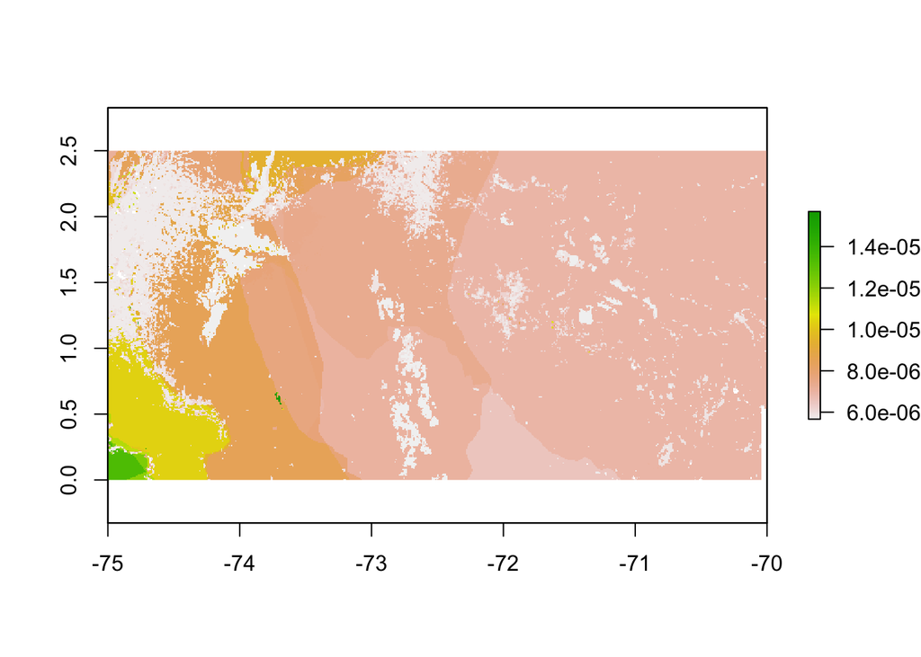

```r
sp.End <- SpeciesEndemism(primRas)
plot(sp.End)
```

## Complementarity

It is often useful to spatially quantify biodiversity data to assess geographically where patterns exist. For example, to find or compare areas that contain more than 50% of species richness, thresholding a raster by a statistical value can be important.

Loading the SDM data and ensuring the names match the phylogeny

```r
# Load binary maps/SDMs
primRas <- stack(list.files(path = paste0(system.file(package="changeRangeR"), "/extdata/DemoData/SDM/colPrimates_binary"), pattern = "\\.tif$", full.names = T))
# Because of species' name resolutions in the phylogeny we use here, we need to rename some of the species in this rasterStack
names(primRas) <- gsub("*_veg", "", names(primRas))
# Drop models that are resolved into one group; Cebus_albifrons
primRas <- dropLayer(primRas, c("Cebus_versicolor", "Cebus_leucocephalus", "Cebus_malitiosus", "Cebus_albifrons"))
oldnames <- names(primRas)
namesToChange <- c("Cebus_all_albifrons", "Cheracebus_lugens", "Cheracebus_medemi", "Lagothrix_lagothricha", "Leontocebus_fuscus", "Plecturocebus_caquetensis", "Plecturocebus_discolor", "Plecturocebus_ornatus", "Saimiri_cassiquiarensis")
newNames <- c("Cebus_albifrons", "Callicebus_lugens", "Callicebus_medemi", "Lagothrix_lagotricha", "Leontocebus_fuscicollis", "Callicebus_caquetensis", "Callicebus_discolor", "Callicebus_ornatus", "Saimiri_sciureus")
oldnames[oldnames %in% namesToChange] <- newNames
names(primRas) <- oldnames
```

Calculate species richness again and convert zeros to NA

```r
SR <- sum(primRas, na.rm = T)
SR[SR == 0] <- NA
```

Calculate the raster value at the 50th percentile

```r
thresholdValue <- quantile(SR, probs = 0.5)
```

Threshold the raster by the chosen value and plot

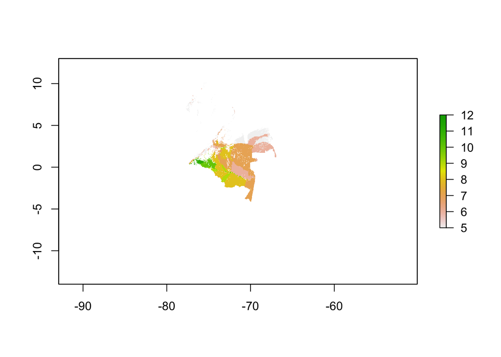

```r
SR[SR < thresholdValue] <- NA
plot(SR)
```

Users can then calculate the overlap of this new raster with a shapefile. For example, a user can find the proportion of 50% of species richness that is protected.

Load protected areas in Colombia and calculate the ratio of overlap

```r
PAs <- st_read(paste0(system.file(package="changeRangeR"), "/extdata/DemoData/shapefiles"), "WDPA_COL_olinguito")
# View the fields
colnames(PAs)
```

```
## [1] "NAME"       "ORIG_NAME"  "DESIG"      "DESIG_ENG"  "DESIG_TYPE"
## [6] "geometry"
```

```r
# Pick the field you are interested in
field <- "DESIG_ENG"
category <- "All"
ratio.Overlap <- ratioOverlap(r = SR, shp = PAs, field = field, category = category, subfield = FALSE)
print(ratio.Overlap)
```

```
## $maskedRange
## $maskedRange[[1]]
## class      : RasterLayer
## dimensions : 3251, 2771, 9008521  (nrow, ncol, ncell)
## resolution : 0.00833, 0.00833  (x, y)
## extent     : -83.04165, -59.95922, -14.03918, 13.04165  (xmin, xmax, ymin, ymax)
## crs        : +proj=longlat +datum=WGS84 +no_defs
## source     : memory
## names      : layer
## values     : 5, 10  (min, max)
##
##
##
## $ratio
## [1] "Percentage of range within All is 0.676%"
##
## $correlation
## NULL
```

Users can also find the amount of species richness is currently protected.

Calculate species richness again and convert zeros to NA

```r
SR <- sum(primRas, na.rm = T)
SR[SR == 0] <- NA
```

Load protected areas in Colombia and calculate what percentage of species richness is currently protected.

```r
PAs <- st_read(paste0(system.file(package="changeRangeR"), "/extdata/DemoData/shapefiles"), "WDPA_COL_olinguito")
# View the fields
colnames(PAs)
```

```
## [1] "NAME"       "ORIG_NAME"  "DESIG"      "DESIG_ENG"  "DESIG_TYPE"
## [6] "geometry"
```

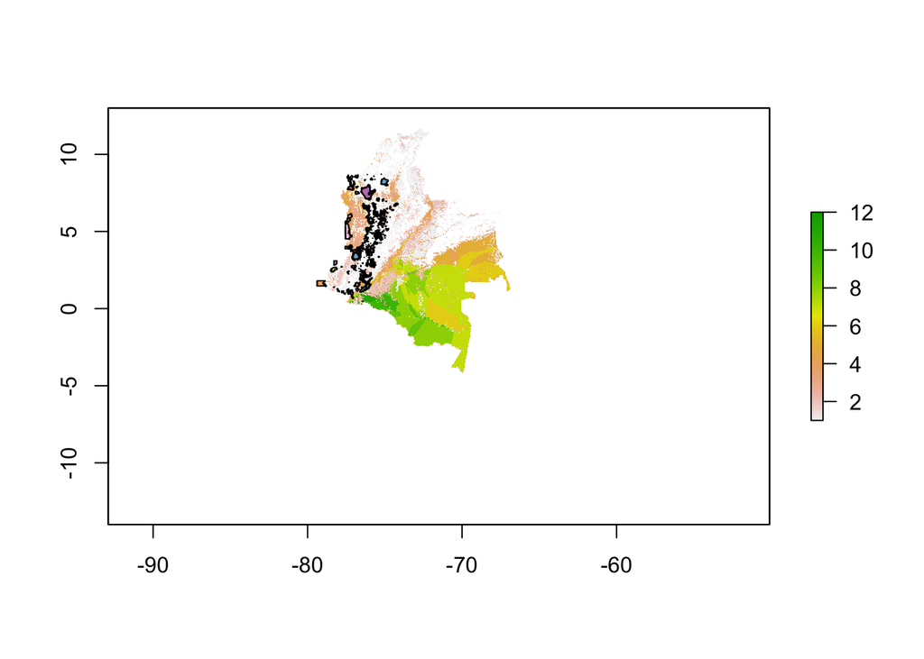

```r
# Pick the field you are interested in
field <- "DESIG_ENG"
category <- "All"
# Mask species richness by protected areas to find richness within protected areas
rmask <- mask(SR, PAs)
# Take a look
plot(SR)
plot(PAs, add = T)
```

```r
comp <- complementarity(ras1 = SR, ras1mask = rmask)
print(comp)
```

```
## $Percent_of_Total
## [1] 1.964951
##
## $Percent_unique_values
##    Var1 Freq.x Freq.y     percent
## 1     1 235159   8710 3.703876951
## 2     2 100331   5280 5.262580857
## 3     3  82448   8070 9.787987580
## 4     4  60662   5974 9.848010287
## 5     5  73223   2863 3.909973642
## 6     6  95872    280 0.292056075
## 7     7 165216     87 0.052658338
## 8     8 105035     12 0.011424763
## 9     9  17963      1 0.005566999
## 10   10  18657      4 0.021439674
## 11   11   5972      0 0.000000000
## 12   12    283      0 0.000000000
```